# Is Technological Innovation Responsible for Economic Growth?

## By Noemi Meraz and Colin Duggan

[figure not shown]

```python
from PIL import Image
img = Image.open('/Users/colinduggan/Desktop/Data/Map.png')
img
```

## Question we were Interested in Addressing:

The internet has, especially in recent years, “added weight to utility status” because it is a leveler; it promotes social mobility, grants access to information and education as well as allows consumer’s access to cheaper goods and services, creating competition. It is indisputable that technological innovation correlates with economic growth, and “because of technological progress, daily life has changed more in the last 200 years than in the preceding 2000 years”. Technological progress is vital for economic growth since it allows productivity to increase, meaning the quantities of factors of production are now able to produce higher levels of output. Therefore, it seems obvious that technological advancement is an explanation for the increased productivity that can be seen across the world today. Since technology is nonrivalrous and oftentime nonexcludable due to it being mostly ideas and not tangible goods, it would seem intuitive that all countries would reap the benefits of technological innovation at very similar levels. This is not the case, however, similar to both physical and human capital, the countries which are at the cutting edge of technology are concentrated in HICs and account for only 14% of the world population. While HICs countries are able to easily innovate, transfer, imitate and use cutting edge technology, it is not easy to do so between HICs and LICs or even MICs. It is obvious that technological gaps exist between countries, therefore the data we researched aimed to answer: Would increased internet access and technological development in poor countries lead to sustainable economic growth and allow them to catch up with developing countries as well as what barriers exist that prevent fast technological transfer? Additionally, how has technology and more specifically internet access affected economic growth in the United States and in the rest of the World? Lastly, what role do tools like secure internet servers and patents protected by governments play in technological innovation?

## Assumptions:

Since private firms are primarily concerned with maximizing profits and raising the quality of their products, a massive part of R&D is done by private firms. It is important to keep this in mind since the pace of technological change will depend extensively on the decisions of private firms. Our data from the World Bank takes this into consideration. Technological Innovation that aids economic growth ranges from railroads and healthcare discoveries to microchips and AI. Spending on R&D encompasses all sectors but the rest of the data we analyze focuses on internet use, mobile cellular subscriptions and patents.

## Definitions:

### Improvement in Technology:

Given quantities of physical and human capital can be combined to produce more output than previously possible.

### Patent:

Grant made by a Government that confers on the creator of the invention the sole right to make, use and sell the invention for a period of time.

## What we looked at:

### Expenditure on R&D as a percent of GDP

How much of total GDP is allocated towards research and development by country income groups. This data encompasses expenditures from four main sectors, Business enterprise, Higher Education, Private non-profit and Government.

### GDP Growth (Change)

In order to see growth or stagnation by country income groups during the same years since data for R&D expenditure and internet usage as well as mobile phone subscriptions, and internet usage.

### Individuals using the Internet as a percent of total Population

How many individuals have internet access and used the internet (in the last three months) via computer, phone, digital assistant, gaming systems etc. during the same years since data for R&D and GDP change.

### Patent Applications (residents)

Patent applications filed through PCT in order to protect inventions of the owner for a period of time. An indicator for appetite in innovation.

### Secure Internet Servers

The number of distinct publicly trusted TLS/SSL certificates. An indicator for trust in using technology within country groups.

### High Technology Exports as a percent of Manufactured Exports

These are exports with high R&D Intensity, i.e. aerospace, computers, scientific instruments, and electrical machinery. In order to see which countries are diffusing technological information.

### Mobile Cellular Subscriptions

Subscriptions to a public mobile telephone service that provides access to the PSTN using cellular technology. Split into postpaid and prepaid subscriptions (in the last three months). In order to see basic infrastructure (power and communication lines) needed to support R&D investments as well as telecommunication investments.

## DAG

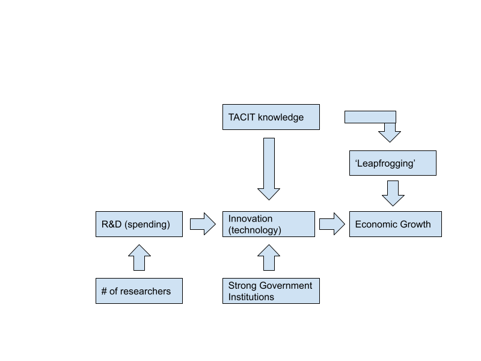

```python
from PIL import Image
dag = Image.open('/Users/colinduggan/Desktop/Data/DAG.png')
dag
```

```python
# Basic Packages
from __future__ import division
import os
from datetime import datetime

# Web & file access
import requests
import io

# Plotting
import matplotlib as mpl
import matplotlib.pyplot as plt
import matplotlib.ticker as mtick

%pylab --no-import-all
%matplotlib inline

import seaborn as sns
sns.set(rc={'figure.figsize':(11.7,8.27)})
sns.set_context("talk")

import plotly.express as px
import plotly.graph_objects as go

from plotnine import ggplot, geom_point, aes, stat_smooth, facet_wrap
# Next line can import all of plotnine, but may overwrite things? Better import each function/object you need
#from plotnine import *

# Data
import pandas as pd
import numpy as np
from pandas_datareader import data, wb

# GIS & maps
import geopandas as gpd
gp = gpd
import georasters as gr
import geoplot as gplt
import geoplot.crs as gcrs
import mapclassify as mc
import textwrap

# Data Munging
from itertools import product, combinations
import difflib
import pycountry
import geocoder
from geonamescache.mappers import country
mapper = country(from_key='name', to_key='iso3')
mapper2 = country(from_key='iso3', to_key='iso')
mapper3 = country(from_key='iso3', to_key='name')

# Paths
pathout = './data/'

if not os.path.exists(pathout):
    os.mkdir(pathout)

pathgraphs = './graphs/'
if not os.path.exists(pathgraphs):
    os.mkdir(pathgraphs)
```

```
Using matplotlib backend: MacOSX
%pylab is deprecated, use %matplotlib inline and import the required libraries.
```

# Research and Development

## Data

```python
import pandas as pd

ResearchandD = (['United States','USA',2.450010061,2.479830027,2.504009962,2.549649954,2.628789902,2.648299932,
                 2.559259892,2.564549923,2.502429962,2.516969919,2.557640076,2.631609917,2.767910004,2.812700033,
                 2.735399961,2.765249968,2.681659937,2.711539984,2.721509933,2.782059908,2.845849991,2.895720005,
                 3.000819921,3.166090012,3.450180054],
                ['High Income Countries','HIC',2.148121738,2.177025997,2.17958534,2.247898015,2.310474301,
                 2.344107954,2.284862762,2.256582767,2.206194667,2.220716503,2.245626817,2.247542199,2.325315486,
                 2.392807086,2.373923752,2.382896725,2.4010098,2.397350519,2.448905441,2.462143193,2.518403818,
                 2.558253602,2.62112682,2.701276182,2.967474365],
                  ['Upper Middle Income Countries', 'UMC', 0.490133191,0.532318023,0,0.573899137,0.684406325,
                   0.717541795,0.778088945,0.820228352,0.847500072,0.902630258,0.922370954,0.972020252,1.016128839,
                   1.194165113,1.22854047,1.217945246,1.333591968,1.388820726,1.434068968,1.538770029,1.575104021,
                   1.569459469,1.607472503,1.700169181,1.99608404],)

RnD = pd.DataFrame(ResearchandD, columns=['Country','Country code','1996','1997','1998','1999','2000','2001','2002',
                                          '2003','2004','2005','2006','2007','2008','2009','2010','2011','2012',
                                          '2013','2014','2015','2016','2017','2018','2019','2020'])
RnD = RnD.transpose()

RnD.columns = RnD.iloc[1]

RnD = RnD.drop('Country')
RnD = RnD.drop('Country code')
RnD.head()
```

| Country code | USA | HIC | UMC |
| --- | --- | --- | --- |
| 1996 | 2.45001 | 2.148122 | 0.490133 |
| 1997 | 2.47983 | 2.177026 | 0.532318 |
| 1998 | 2.50401 | 2.179585 | 0.0 |
| 1999 | 2.54965 | 2.247898 | 0.573899 |
| 2000 | 2.62879 | 2.310474 | 0.684406 |

## Plotting

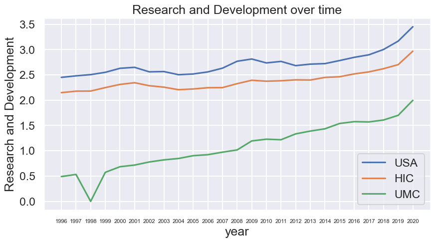

```python
plt.figure(figsize=(10,5))
for column in RnD.columns:
    plt.plot(RnD.index, RnD[column], label = column)
plt.xlabel('year')
plt.ylabel('Research and Development')
plt.xticks(fontsize=8)
plt.title('Research and Development over time')
plt.legend()
```

## LIMITATIONS:

Based on this graph the exact amount of money HICs income group needs in order to gauge in Dollars how much investment is needed to maintain the “cutting edge” development status of HICs. Small disparities between how each country measures their expenditure on R&D also exist.

# high tech exports

# Data

```python
hightechexports = (['United States','USA',29.8795679,28.40443039,24.34746224,22.60666836,20.61303501,
                    20.1632972,20.1783052,20.46714382,21.38094103,22.41134286,19.25881811,18.4740538,
                    18.6726519,19.48384895],
                   ['High Income Countries','HIC',20.43820003,19.87546514,21.18774761,20.53838553,
                    18.76589248,18.56003996,18.46937438,18.53468307,19.39413201,19.67772633,
                    23.72460594,19.91347846,20.18386953,21.3266405],
                  ['Upper Middle Income Countries', 'UMC', 20.45428339,19.19244387,23.67920685,23.63330294,
                   21.81998023,22.45516796,23.46257881,23.05555905,24.35363134,24.20309099,24.13427746,
                   24.15558193,23.89397,25.05754318],
                  ['Lower Middle Income Countries','LMC', np.NaN,np.NaN,np.NaN,6.639240758,5.915946051,6.157072053,
                   6.066798746,6.411731673,6.404816257,5.95583257,9.623017449,10.24744747,11.89614292,
                   12.85420047],
                  ['Low Income Countries','LIC',np.NaN,1.570914735,1.685781201,1.468712182,np.NaN,np.NaN,np.NaN,
                   np.NaN,5.181022254,6.458697683,3.640347666,3.870409896,5.068708271,3.363027944])

hte = pd.DataFrame(hightechexports, columns=['Country','Country code','2007','2008','2009','2010','2011','2012',
                                             '2013','2014','2015','2016','2017','2018','2019','2020'])
hte = hte.transpose()

hte.columns = hte.iloc[1]

hte = hte.drop('Country')
hte = hte.drop('Country code')
hte.head()
```

| Country code | USA | HIC | UMC | LMC | LIC |
| --- | --- | --- | --- | --- | --- |
| 2007 | 29.879568 | 20.4382 | 20.454283 | NaN | NaN |
| 2008 | 28.40443 | 19.875465 | 19.192444 | NaN | 1.570915 |
| 2009 | 24.347462 | 21.187748 | 23.679207 | NaN | 1.685781 |
| 2010 | 22.606668 | 20.538386 | 23.633303 | 6.639241 | 1.468712 |
| 2011 | 20.613035 | 18.765892 | 21.81998 | 5.915946 | NaN |

## Plotting

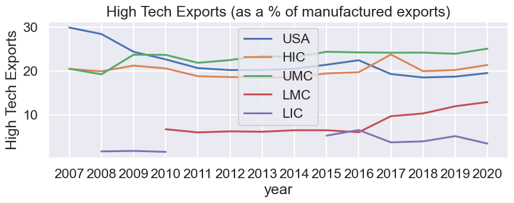

```python
plt.figure(figsize=(10,3))
for column in hte.columns:
    plt.plot(hte.index, hte[column], label = column)
plt.xlabel('year')
plt.ylabel('High Tech Exports')
plt.title('High Tech Exports (as a % of manufactured exports)')
plt.legend()
```

## Analysis:

High-technology exports are products with high research and development intensity, like in aerospace, computers, pharmaceuticals, scientific instruments, and electrical machinery. It can be seen that upper middle income countries have the highest value of high technology exports as a percentage of manufactured exports. This can be attributed to China and their recent interest in production and massive levels of output. Internationally, China sells a lot of raw materials, and finished products around the world.

# Individuals using the internet

## Data

```python
users= (['United States','USA',0.784728502,1.163193726,1.724202539,2.271673294,4.862780635,9.237088297,16.41935296,
         21.61640097,30.09319659,35.84872446,43.07916264,49.08083159,58.78540388,61.69711712,64.75825648,67.96805292,
         68.93119327,75,74,71,71.69,69.72946076,74.7,71.4,73,74.55420245,85.54442129,87.27488917,88.49890317,
         89.43028486,90.9],
        ['High Income Countries','HIC',0.254363037,0.411485261,0.654116105,0.932192827,1.879081409,3.530147017,
         6.492213455,10.25485849,15.44369571,22.31074619,29.93519159,35.90892379,44.19873063,48.87979226,54.09019994,
         57.85879245,60.59586327,65.97176702,68.14191012,69.45772189,71.58539317,72.14159627,74.88504398,76.29465745,
         77.97921635,79.43867762,83.76970307,85.33294644,87.12906287,88.71080516,89.55406103],
        ['Upper Middle Income Countries', 'UMC', 0,0.000757561,0.002637343,0.008096535,0.02126415,0.052919879,
         0.125997226,0.261466861,0.599229914,1.270323322,2.536929726,3.663949865,6.035293919,7.930316012,
         9.956681551,11.5326724,14.09392231,18.9050854,24.07795688,29.7378981,34.80775046,39.37463189,43.52579667,
         46.69080588,49.27894047,52.5361365,56.00287225,58.58334283,63.00544077,67.57511659,73.32616378],
        ['Lower Middle Income Countries','LMC',0,0,0,0.000140684,0.001345715,0.017325644,0.037981924,0.074326873,0.1574614,0.285306654,0.578562242,0.887769035,1.659654644,2.207168698,3.031518773,3.771129158,4.612480699,5.73897953,6.816498365,7.84292415,10.64135124,12.79057401,14.37279891,16.10980027,18.50736713,20.9458754,23.67811691,26.74539878,30.08918395,36.42944581,45.10176749],
        ['Low Income Countries','LIC',0,0,0,0,0.000181505,0.000446398,0.002009638,0.009834967,0.02330475,
         0.054390858,0.081050236,0.124828429,0.298729119,0.435984734,0.594405706,0.879339856,1.139462349,2.228458875,
         2.073364875,2.710321653,3.326847659,3.786672004,4.596026927,5.37036672,7.008198374,9.147539109,11.07833615,
         13.75559123,16.22662208,18.13061168,20.58744486])

u = pd.DataFrame(users, columns=['Country','Country code','1990','1991','1992','1993','1994','1995','1996','1997',
                                 '1998','1999','2000','2001','2002','2003','2004','2005','2006','2007','2008',
                                 '2009','2010','2011','2012','2013','2014','2015','2016','2017','2018','2019',
                                 '2020'])
u = u.transpose()

u.columns = u.iloc[1]

u = u.drop('Country')
u = u.drop('Country code')
u.head()
```

| Country code | USA | HIC | UMC | LMC | LIC |
| --- | --- | --- | --- | --- | --- |
| 1990 | 0.784729 | 0.254363 | 0.0 | 0.0 | 0.0 |
| 1991 | 1.163194 | 0.411485 | 0.000758 | 0.0 | 0.0 |
| 1992 | 1.724203 | 0.654116 | 0.002637 | 0.0 | 0.0 |
| 1993 | 2.271673 | 0.932193 | 0.008097 | 0.000141 | 0.0 |
| 1994 | 4.862781 | 1.879081 | 0.021264 | 0.001346 | 0.000182 |

## Plotting

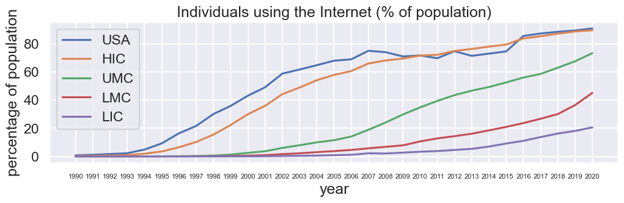

```python
plt.figure(figsize=(12,3))
for column in u.columns:
    plt.plot(u.index, u[column], label = column)
plt.xlabel('year')
plt.xticks(fontsize=8)
plt.ylabel('percentage of population')
plt.title('Individuals using the Internet (% of population)')
plt.legend()
```

# Mobile cellular subscriptions

## Data

```python
cell_subs= (['United States','USA',0,0,0,0,0.038445905,0.14146081,0.280860174,0.502281572,0.836569536,
             1.405118706,2.095449994,2.96895054,4.293056805,6.168585393,9.203138701,12.74143303,16.41343526,
             20.35683377,25.15099311,30.89124914,38.86183584,45.14982121,49.35962707,55.42732036,63.21739536,
             69.05236638,77.10934813,82.93180628,86.09952013,89.5449638,92.26777096,95.44904589,97.06859919,
             98.19768385,111.5562164,119.1439209,122.5945483,123.0448345,106.4646825,108.0926533,106.1855544],
            ['High Income Countries','HIC',0.002489746,0.008855744,0.01403844,0.021611661,0.036347033,0.083779425,
             0.146881348,0.254376842,0.427685986,0.72065096,1.058030276,1.507612321,2.099718609,2.996703616,
             4.707855606,7.441753057,11.61279238,16.41892785,23.62955182,34.70434326,48.41836915,57.26240872,
             62.85993405,68.91954038,75.83135846,83.26511671,91.05758602,99.67887554,104.4890574,107.6386397,
             109.4973581,113.2100366,115.5305622,117.2958174,121.4438505,123.1642361,124.6144332,124.6984241,
             121.1669907,122.4949291,122.274273],
            ['Upper Middle Income Countries', 'UMC', 0,0,0,0,0,0,0.000655926,0.001566904,0.003143834,0.006216187,
             0.014852061,0.028584504,0.057115805,0.112640195,0.246258642,0.482702884,0.838263917,1.522992003,
             2.48832919,4.467396777,8.057334017,12.42616145,17.22318327,22.59505015,30.14805653,39.04174369,
             47.36964348,56.48568557,65.79585522,73.83693127,81.73235467,89.0435935,96.15912593,103.5675255,
             105.7882825,105.5982151,108.0433371,111.2726695,118.2649863,121.8319885,119.5627102],
            ['Lower Middle Income Countries','LMC',0,0,0,0,0.000100371,0.000114058,0.000248699,0.000492924,
             0.000654014,0.000912221,0.001366954,0.003992359,0.00606828,0.011036605,0.018529658,0.052827379,
             0.114679222,0.208317513,0.289014491,0.515106521,1.054349275,1.94561468,2.991954452,4.958859527,
             7.936936439,12.9784013,21.18188892,30.69932316,42.29649746,53.56383737,66.5944165,76.23804977,
             78.90984537,82.21555157,86.58261745,88.99454891,94.97881762,97.81217779,96.50220051,99.36374295,
             100.0473165],
            ['Low Income Countries','LIC',0,0,0,0,0,0,0,0,0,0,0,0,0.000626817,0.002091391,0.00354162,0.007138783,
             0.010758191,0.017788268,0.040653984,0.076439845,0.201598472,0.475230007,0.872937453,1.729912077,
             3.003952326,4.457264686,7.462389567,11.99208091,17.82915346,22.25507943,27.88942004,35.3681134,
             40.62514248,46.85446019,52.49906204,55.69037244,53.95433738,54.12481668,61.49837217,56.68697909,
             59.10541657])

cs = pd.DataFrame(cell_subs, columns=['Country','Country code','1980','1981','1982','1983','1984','1985','1986',
                                      '1987','1988','1989','1990','1991','1992','1993','1994','1995','1996','1997',
                                      '1998','1999','2000','2001','2002','2003','2004','2005','2006','2007','2008',
                                      '2009','2010','2011','2012','2013','2014','2015','2016','2017','2018','2019',
                                      '2020'])
cs = cs.transpose()

cs.columns = cs.iloc[1]

cs = cs.drop('Country')
cs = cs.drop('Country code')
cs.head()
```

| Country code | USA | HIC | UMC | LMC | LIC |
| --- | --- | --- | --- | --- | --- |
| 1980 | 0.0 | 0.00249 | 0.0 | 0.0 | 0.0 |
| 1981 | 0.0 | 0.008856 | 0.0 | 0.0 | 0.0 |
| 1982 | 0.0 | 0.014038 | 0.0 | 0.0 | 0.0 |
| 1983 | 0.0 | 0.021612 | 0.0 | 0.0 | 0.0 |
| 1984 | 0.038446 | 0.036347 | 0.0 | 0.0001 | 0.0 |

## Plotting

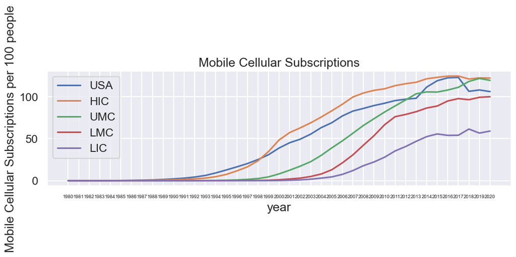

```python
plt.figure(figsize=(12,3))
for column in cs.columns:
    plt.plot(cs.index, cs[column], label = column)
plt.xlabel('year')
plt.xticks(fontsize=7)
plt.ylabel('Mobile Cellular Subscriptions per 100 people')
plt.title('Mobile Cellular Subscriptions')
plt.legend()
```

## Analysis:

Digital connectivity can directly affect the productivity of firms, workers, and other inputs in the production process. Simple access to the internet helps workers be more efficient and on the demand side, internet access opens markets to cheaper goods and allows for the diffusion of information to be close to instantaneous. It's no surprise that HICs are at the top of internet users with UMICs trailing behind them. HICs and a growing number of UMICs sectors of production are dependent on existing and innovative technology. Still, even UMICs, LMICs and LICs a substantial gap exists between individuals readily able to access the internet. Among HICs not having access to the internet would seem abnormal. Mobile cellular subscriptions are a more optimistic measure of convergence among all country income groups. Especially in recent years, countries across the world except LICs have bridged the gap between having a cellular device. This supports the theory that as long as technologically advanced countries continue to do R&D, they will eventually bring improvements to underdeveloped countries as well.

## LIMITATIONS:

Data does not take into consideration the gap between cellular devices that allow for internet access and those who do not. Nor does it capture the disparity within countries (geographic regions) of who can afford a cell phone subscription or the specific devices people use for internet access.

# Secure Internet Servers

## Data

```python
internetservers= (['United States','USA',767662,930471,1205823,1360046,1633177,2039539,3694357,9863566,21517004,
                   40706354,46678110],
                  ['Japan','JPN',70810,86878,116093,134421,175217,191255,267900,758209,1476696,2361325,2884902],
                  ['Mexico', 'MEX',1531,2001,3146,3756,4930,7054,14758,23144,28487,34635,41615],
                  ['India','IND',2061,2842,5704,7880,10941,15313,50723,164791,254032,531807,662298],
                  ['Sierra Lione','SLE', 3,4,9,7,5,7,11,14,0,41,52])

sis = pd.DataFrame(internetservers, columns=['Country','Country code','2010','2011','2012','2013','2014','2015',
                                             '2016','2017','2018','2019','2020'])
sis = sis.transpose()

sis.columns = sis.iloc[1]

sis = sis.drop('Country')
sis = sis.drop('Country code')
sis.head()
```

| Country code | USA | JPN | MEX | IND | SLE |
| --- | --- | --- | --- | --- | --- |
| 2010 | 767662 | 70810 | 1531 | 2061 | 3 |
| 2011 | 930471 | 86878 | 2001 | 2842 | 4 |
| 2012 | 1205823 | 116093 | 3146 | 5704 | 9 |
| 2013 | 1360046 | 134421 | 3756 | 7880 | 7 |
| 2014 | 1633177 | 175217 | 4930 | 10941 | 5 |

## Plotting

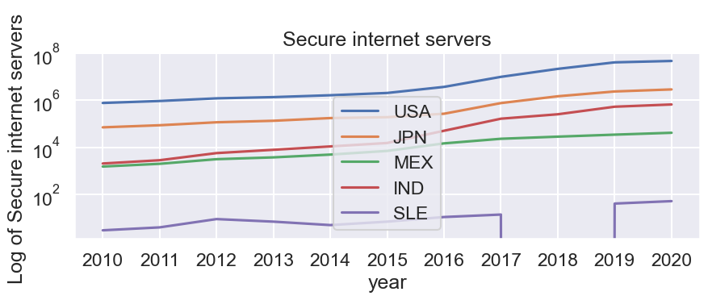

```python
plt.figure(figsize=(10,3))
for column in sis.columns:
    plt.plot(sis.index, sis[column], label = column)
plt.xlabel('year')
plt.ylabel('Log of Secure internet servers ')
plt.yscale('log')
plt.title('Secure internet servers')
plt.legend()
```

# Patents

## Data

```python
patents = (['United States','USA',62098,62404,63316,59391,61841,63673,65195,68315,75192,82370,90643,87955,92425,
            99955,107233,123962,106892,119214,134733,149251,164795,177513,184245,188941,189536,207867,221784,241347,
            231588,224912,241977,247750,268782,287831,285096,288335,295327,293904,285095,285113,269586],
            ['High Income Countries','HIC',0,0,0,0,0,0,0,0,0,0,0,0,0,0,0,0,0,690700,706700,735400,804200,816900,
             805800,821000,851300,886700,886500,898400,888200,841600,861700,868300,899800,916300,912900,912900,
             917400,911300,900300,900200,870300],
            ['Upper Middle Income Countries', 'UMC',0,0,0,0,0,0,0,0,0,0,0,0,0,0,0,0,0,37000,39600,45700,60000,66900,
             76000,95600,104800,135300,170400,207000,253900,284200,340900,462100,584600,754800,845100,1018100,
             1253900,1292700,1441100,1289800,1391200],
            ['Lower Middle Income Countries','LMC',0,0,0,0,0,0,0,0,0,0,0,0,0,0,0,0,0,9100,10000,10000,10200,12200,
             6800,7800,10200,10700,11600,12300,11800,11900,25700,26200,26100,28700,32400,32800,35100,38800,36300,
             41100,42400],
            ['Low Income Countries','LIC',0,0,0,0,0,0,0,0,0,0,0,0,0,0,0,0,0,200,200,200,400,300,300,400,400,6100,
             6600,7300,8200,8700,8700,8500,9000,700,600,700,600,600,800,600,600])

p = pd.DataFrame(patents, columns=['Country','Country code','1980','1981','1982','1983','1984','1985','1986',
                                      '1987','1988','1989','1990','1991','1992','1993','1994','1995','1996','1997',
                                      '1998','1999','2000','2001','2002','2003','2004','2005','2006','2007','2008',
                                      '2009','2010','2011','2012','2013','2014','2015','2016','2017','2018','2019',
                                      '2020'])
p = p.transpose()

p.columns = p.iloc[1]

p = p.drop('Country')
p = p.drop('Country code')
p.head()
```

| Country code | USA | HIC | UMC | LMC | LIC |
| --- | --- | --- | --- | --- | --- |
| 1980 | 62098 | 0 | 0 | 0 | 0 |
| 1981 | 62404 | 0 | 0 | 0 | 0 |
| 1982 | 63316 | 0 | 0 | 0 | 0 |
| 1983 | 59391 | 0 | 0 | 0 | 0 |
| 1984 | 61841 | 0 | 0 | 0 | 0 |

## Plotting

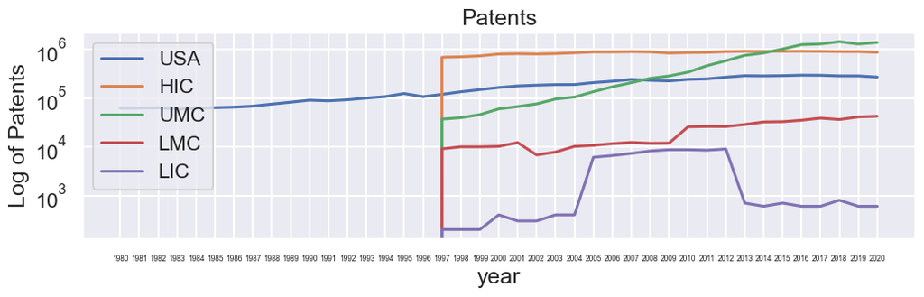

```python
plt.figure(figsize=(12,3))
for column in p.columns:
    plt.plot(p.index, p[column], label = column)
plt.xlabel('year')
plt.xticks(fontsize=6)

plt.yscale('log')
plt.ylabel('Log of Patents')
plt.title('Patents')
plt.legend()
```

## ANALYSIS:

The most important way the government can incentivize R&D is through patent protection, this protects unique ideas from being immediately stolen and allows for the creator to profit from their work. Patents used to provide legal protection against copying of innovations, is the most important way Government aids R&D because Patent protection also provides an incentive to invent thus speeding up technological change. Developing countries enforce property rights very loosely, and researchers as well as entrepreneurs know they will not gain a return on investment, therefore have no interest in doing so. LIC and LMIC countries remain very low in Patent applications further maintaining low levels of technological innovation, we can see in this graph that UMIC countries patent applications actually surpass HIC and the U.S. This trend didn’t align with the rest of our data, so we decided to investigate how this happened. After researching we found that China almost single handedly accounted for the UMIC countries (as it is classified) to surpass the patent applications of HICs. This is because China overfiles its number of patents in order to seem more trustworthy to investors, but only about “10% of China’s patents have market value”. As far as why Secure Internet servers are an important indicator for potential convergence of developing and developed countries in terms of technology is because they provide the groundwork for potential investment in R&D. Government investment alone is not enough to support R&D, secure internet servers allow for telecommunication markets to maintain stable enough to connect within and across countries. Stable internet servers help “develop standards, harmonize information and communications technology statistics, and build statistical capacity in developing countries”.

# GDP Growth

## Data

```python
gdpgrowth= (['United States','USA',-0.256749674,2.537719307,-1.802887409,4.583913355,7.23663315,4.169656223,
             3.462645971,3.45925199,4.177061291,3.67264815,1.885964957,-0.108264791,3.522440527,2.751781051,
             4.02879326,2.684217272,3.772565499,4.447174945,4.481394432,4.794499045,4.077159479,0.954338729,
             1.695942923,2.796209101,3.852552601,3.48322032,2.782810626,2.010507552,0.122188443,-2.599888351,
             2.708856694,1.54989495,2.280687603,1.841875395,2.287775933,2.706369582,1.667472076,2.255680481,
             2.918856897,2.288869868,-3.404589652,5.671107191],
            ['High Income Countries','HIC',1.249316012,1.901357932,-0.137786893,2.823504815,4.666271674,3.536736501,
             3.310810707,3.472927665,4.767399848,3.925812088,3.103923286,1.435159748,2.192571264,1.357614085,
             3.291097179,2.863869085,3.078949112,3.503807096,2.845158439,3.442517165,4.0892442,1.460358823,
             1.578898586,2.238915045,3.444709567,2.930612406,3.145639572,2.830415156,0.543595151,-3.229395654,
             3.013649618,1.945578775,1.407879943,1.516072268,2.074666699,2.367795928,1.825683771,2.374700666,
             2.340666232,1.779924663,-4.496496728,5.107989855],
            ['Upper Middle Income Countries', 'UMC',6.59610062,2.186349144,2.032410808,0.97645449,6.242404259,
             4.983046778,4.859136105,5.568666723,3.856215378,2.38975234,1.018359507,1.110175143,1.134415702,
             4.244815433,3.758483161,3.529974112,5.274100964,5.849120424,3.076382056,3.668988323,6.436414593,
             3.615254904,4.742874994,5.991455397,8.138140213,7.74631105,8.895950597,9.647478903,6.485588933,
             2.714095293,8.419120158,6.922080704,5.92143403,5.575726641,4.722885861,4.304537569,4.230111778,
             5.231114522,4.941993001,4.093769224,-0.597241944,7.39786379],
            ['Lower Middle Income Countries','LMC',1.150637678,1.710708958,4.654281315,3.909543634,1.98537213,
             3.545546589,2.26268558,3.139686033,4.693694508,4.486414037,4.974796343,2.643573118,2.958196533,
             1.409553505,2.488638397,4.659285453,5.975803756,3.596996877,1.3579986,4.235764922,4.423942844,
             4.109079582,4.830677605,6.161188774,6.557021343,6.083015063,6.43501982,6.869574457,4.231763348,
             4.649439744,6.600893102,4.775749654,4.475866424,4.978196297,5.554989874,5.015991066,5.70922875,
             5.059489894,4.824460346,3.784775134,-3.322305358,5.59139502],
            ['Low Income Countries','LIC',0,0,1.593461697,1.771561636,-1.314313824,0.04147594,3.018007469,
             5.90680367,3.617449582,1.440749051,-1.733343414,1.827416525,1.154610686,1.888108016,1.57317881,
             5.039107079,5.736026301,6.928152271,3.754463489,2.552915508,3.326956873,4.9273992,4.379056461,
             4.969191234,6.010733035,6.490514493,5.960122007,6.170517922,5.405013964,3.542885811,6.772108651,
             0.606540018,-4.106733124,3.249023516,4.343628912,-0.174958387,2.363293125,2.963035506,3.114058805,
             3.823595066,0.10476527,3.013900152])

gg = pd.DataFrame(gdpgrowth, columns=['Country','Country code','1980','1981','1982','1983','1984','1985','1986',
                                      '1987','1988','1989','1990','1991','1992','1993','1994','1995','1996','1997',
                                      '1998','1999','2000','2001','2002','2003','2004','2005','2006','2007','2008',
                                      '2009','2010','2011','2012','2013','2014','2015','2016','2017','2018','2019',
                                      '2020', '2021'])
gg = gg.transpose()

gg.columns = gg.iloc[1]

gg = gg.drop('Country')
gg = gg.drop('Country code')
gg.head()
```

| Country code | USA | HIC | UMC | LMC | LIC |
| --- | --- | --- | --- | --- | --- |
| 1980 | -0.25675 | 1.249316 | 6.596101 | 1.150638 | 0.0 |
| 1981 | 2.537719 | 1.901358 | 2.186349 | 1.710709 | 0.0 |
| 1982 | -1.802887 | -0.137787 | 2.032411 | 4.654281 | 1.593462 |
| 1983 | 4.583913 | 2.823505 | 0.976454 | 3.909544 | 1.771562 |
| 1984 | 7.236633 | 4.666272 | 6.242404 | 1.985372 | -1.314314 |

## Plotting

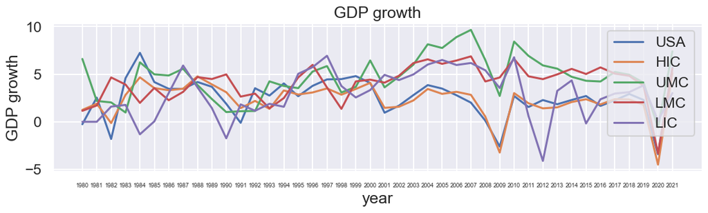

```python
plt.figure(figsize=(13,3))
for column in gg.columns:
    plt.plot(gg.index, gg[column], label = column)
plt.xlabel('year')
plt.xticks(fontsize=6.5)
plt.ylabel('GDP growth')
plt.title('GDP growth')
plt.legend()
```

## ANALYSIS:

Over long periods of time the impact of technological advancement leads to consistent economic growth, ceteris paribus. Gross Domestic Product, is dependent on a country’s output and is a good indicator for growth. Expansions cause GDP to rise and contractions or recessions cause GDP to fall. For example, the graph shows a drastic drop in GDP during 2008 and 2009 because of the housing market crash. During the COVID-19 pandemic, the markets crashed again and caused GDP to fall. Countries have bounced back from COVID well making up for missed revenue by building the economy back together. During COVID, the world took to the internet to maintain connections with other people. This can be seen in the data through internet usage and Research and Development increasing. These countries invested in R&D to because to maintain the current level of technological process, it requires even greater input into R&D.

## CONCLUSION:

Technological progress has been a major source of economic growth across all countries and income levels. But, some countries have less access to the internet and therefore cannot benefit from the technology that exists. Technological change as well as research and development has continued at a “historically unprecedented rate. This is because spending more on R&D lowers output in the short run but will raise it in the long run, and an increase in R&D leads to a permanent increase in the growth rate of output. This is a crucial part of technological change, it allows an economy to transcend the limitations imposed by diminishing returns, as long as A can get bigger, income per capita can continue to grow.

## Sources:

https://www.worldbank.org/en/home

https://www.cigionline.org/articles/what-do-chinas-high-patent-numbers-really-mean/

https://www.abebooks.com/9780321795731/Economic-Growth-3rd-Edition-Weil-0321795733/plp